# Decorrelation-Based Feature Discovery: NHNES

Jose Tamez

2024-01-10

# 1 Effect of UPSTM-Based Decorrelation on Feature Discovery

### 1.0.1 Loading the libraries

```r
library("FRESA.CAD")
library(readxl)
library(igraph)
library(umap)
library(tsne)
library(entropy)

op <- par(no.readonly = TRUE)
pander::panderOptions('digits', 3)
pander::panderOptions('table.split.table', 400)
pander::panderOptions('keep.trailing.zeros',TRUE)
```

## 1.1 Material

Data source:

https://www.kaggle.com/datasets/cdc/national-health-and-nutrition-examination-survey?select=labs.csv

Details:

https://www.cdc.gov/Nchs/Nhanes/about_nhanes.htm

```r
demographic <- as.data.frame(read_excel("~/GitHub/LatentBiomarkers/Data/NHNES/demographic.xlsx"))
demographiDesc <- as.data.frame(read_excel("~/GitHub/LatentBiomarkers/Data/NHNES/demographic.xlsx",sheet = "Sheet1"))

rownames(demographic) <- demographic$SEQN
demographic$SEQN <- NULL

vartokeep <- demographiDesc[demographiDesc$Keep=="Yes",1]
demographic <- demographic[,vartokeep]

keepColumn <- apply(!is.na(demographic),2,sum)/nrow(demographic) > 0.75
demographic <- demographic[,keepColumn]
demographic <- demographic[complete.cases(demographic),]

## Examination data
examination <- as.data.frame(read_excel("~/GitHub/LatentBiomarkers/Data/NHNES/examination.xlsx"))
examinationDesc <- as.data.frame(read_excel("~/GitHub/LatentBiomarkers/Data/NHNES/examination.xlsx",sheet = "Sheet1"))
rownames(examination) <- examination$SEQN
examination$SEQN <- NULL

bpresDI <- examination[,c("BPXDI1","BPXDI2","BPXDI3","BPXDI4")]
examination[,c("BPXDI1","BPXDI2","BPXDI3","BPXDI4")] <- NULL
bpresDIM <- apply(bpresDI,1,mean,na.rm=TRUE)
summary(bpresDIM)
```

```
#>    Min. 1st Qu.  Median    Mean 3rd Qu.    Max.    NA's
#>    0.00   58.00   66.67   65.44   74.67  128.00    2282
```

```r
bpresSY <- examination[,c("BPXSY1","BPXSY2","BPXSY3","BPXSY4")]
examination[,c("BPXSY1","BPXSY2","BPXSY3","BPXSY4")] <- NULL
bpresSYM <- apply(bpresSY,1,mean,na.rm=TRUE)
summary(bpresSYM)
```

```
#>    Min. 1st Qu.  Median    Mean 3rd Qu.    Max.    NA's
#>   64.67  106.00  115.33  118.31  128.00  228.67    2282
```

```r
examination$PEASCST1 <- NULL
examination$bpresDIM <- bpresDIM
examination$bpresSYM <- bpresSYM

keepColumn <- apply(!is.na(examination),2,sum)/nrow(examination) > 0.75
examination <- examination[,keepColumn]
keepColumnVar <- !is.na(apply(examination,2,var,na.rm = TRUE))
examination <- examination[,keepColumnVar]
examination <- examination[complete.cases(examination),]
examination <- examination[examination$bpresDIM>0,]



## questionnaire data
questionnaire <- as.data.frame(read_excel("~/GitHub/LatentBiomarkers/Data/NHNES/questionnaire.xlsx"))
questionnaireDesc <- as.data.frame(read_excel("~/GitHub/LatentBiomarkers/Data/NHNES/questionnaire.xlsx",sheet = "Sheet1"))
rownames(questionnaire) <- questionnaire$SEQN
questionnaire$SEQN <- NULL
table(questionnaire$MCQ010)
```

```
#>
#>    1    2    7    9
#> 1538 8222    1    8
```

```r
#keepColumn <- apply(!is.na(questionnaire),2,sum)/nrow(questionnaire) > 0.85
#questionnaire <- questionnaire[,keepColumn]
#keepColumnVar <- !is.na(apply(questionnaire,2,var,na.rm = TRUE))
#questionnaire <- questionnaire[,keepColumnVar]
#questionnaire <- questionnaire[complete.cases(questionnaire),]
#keeprow <- apply(questionnaire,2,max) < 9000
#questionnaire <- questionnaire[keeprow,]
#table(questionnaire$MCQ010)

## Diabetes
Diabetes <- questionnaire$MCQ010
names(Diabetes) <- rownames(questionnaire)
Diabetes <- Diabetes[!is.na(Diabetes)]
Diabetes <- Diabetes[Diabetes<3]
table(Diabetes)
```

```
#> Diabetes
#>    1    2
#> 1538 8222
```

```r
## Depression
depression <- questionnaire[,c("DPQ010","DPQ020","DPQ030","DPQ040","DPQ050","DPQ060","DPQ070","DPQ080","DPQ090")]
depression[depression>5] <- NA
depressionTot <- apply(depression,1,sum,na.rm=TRUE)
donnow <- apply(is.na(depression),1,sum) == 9
depressionTot <- depressionTot[!donnow]
table(depressionTot)
```

```
#> depressionTot
#>    0    1    2    3    4    5    6    7    8    9   10   11   12   13   14   15
#> 1718  852  631  470  360  233  214  162  137  104   90   66   53   51   57   31
#>   16   17   18   19   20   21   22   23   24   25   27
#>   39   26   27   19   16   12   11    4    7    4    3
```

```r
## The labs data
labs <- as.data.frame(read_excel("~/GitHub/LatentBiomarkers/Data/NHNES/labs.xlsx"))
labsDesc <- as.data.frame(read_excel("~/GitHub/LatentBiomarkers/Data/NHNES/labs.xlsx",sheet = "Sheet1"))

rownames(labs) <- labs$SEQN
labs$SEQN <- NULL

keepColumn <- apply(!is.na(labs),2,sum)/nrow(labs) > 0.75
labs <- labs[,keepColumn]
keepColumnVar <- !is.na(apply(labs,2,var,na.rm = TRUE))
labs <- labs[,keepColumnVar]
labs <- labs[complete.cases(labs),]

includeIDS <- rownames(labs)[rownames(labs) %in% rownames(examination)]
includeIDS <- includeIDS[includeIDS %in% rownames(demographic)]

includeIDS <- includeIDS[includeIDS %in% names(Diabetes)]

Diab <- Diabetes[includeIDS]
table(Diab)
```

```
#> Diab
#>    1    2
#>  992 5006
```

```r
NHNES <- cbind(demographic[includeIDS,],examination[includeIDS,],labs[includeIDS,])
NHNES$Diab <- Diab

table(NHNES$Diab)
```

```
#>
#>    1    2
#>  992 5006
```

```r
## Only Adults in this experiment
NHNES <- NHNES[NHNES$RIDAGEYR >= 20,]

NHNES$Diab <- 1*(NHNES$Diab == 1)

table(NHNES$Diab)
```

```
#>
#>    0    1
#> 3664  650
```

```r
includeIDS <- rownames(NHNES)
includeIDS <- includeIDS[includeIDS %in% names(depressionTot)]
depressionTot <- depressionTot[includeIDS]
NHNESDep <- cbind(NHNES[includeIDS,],depressionTot)

NHNESDep$depressionTot <- log(NHNESDep$depressionTot+1)

tbdep <- table(NHNESDep$depressionTot)
genderDiab <- NHNESDep[,c("RIAGENDR","Diab")]

isContinuous <- sapply(apply(NHNESDep,2,unique),length) > 4
sum(isContinuous)
```

```
#> [1] 63
```

```r
NHNESDep <- cbind(NHNESDep[,isContinuous],genderDiab)

table(NHNESDep$RIAGENDR)
```

```
#>
#>    1    2
#> 2059 2094
```

```r
colnames(NHNESDep)[sapply(apply(NHNESDep,2,unique),length) < 10]
```

```
#>  [1] "OHX04TC"  "OHX06TC"  "OHX10TC"  "OHX11TC"  "OHX13TC"  "OHX20TC"
#>  [7] "OHX25TC"  "OHX29TC"  "LBDBANO"  "RIAGENDR" "Diab"
```

#### 1.1.0.1 Standarize the names for the reporting

```r
studyName <- "NHNES"
dataframe <- NHNESDep
outcome <- "RIDAGEYR"

thro <- 0.40
cexheat <- 0.35
loops <- 30
```

## 1.2 Generaring the report

### 1.2.1 Libraries

Some libraries

```r
library(psych)
library(whitening)
library("vioplot")
library("rpart")
library(multiColl)
library(car)

source("C:/Users/jtame/Documents/GitHub/LatentBiomarkers/RMD/RepeatedLinearCV.R")
```

### 1.2.2 Data specs

```r
pander::pander(c(rows=nrow(dataframe),col=ncol(dataframe)-1))
```

| rows | col |
| --- | --- |
| 4153 | 64 |

```r
varlist <- colnames(dataframe)
varlist <- varlist[varlist != outcome]

largeSet <- length(varlist) > 1500
```

### 1.2.3 Training and testing sets

```r
set.seed(1)
trainsamples <- sample(nrow(dataframe),3*nrow(dataframe)/4)

trainingset <- dataframe[trainsamples,]
testingset <- dataframe[-trainsamples,]

pander::pander(t(summary(trainingset)))
```

| **RIDAGEYR** | Min. :20.00 | 1st Qu.:33.00 | Median :47.00 | Mean :48.03 | 3rd Qu.:62.00 | Max. :80.00 |
| --- | --- | --- | --- | --- | --- | --- |
| **WTINT2YR** | Min. : 5735 | 1st Qu.: 19354 | Median : 28735 | Mean : 41781 | 3rd Qu.: 59117 | Max. :167885 |
| **WTMEC2YR** | Min. : 6107 | 1st Qu.: 19999 | Median : 29753 | Mean : 43054 | 3rd Qu.: 60384 | Max. :171075 |
| **PEASCTM1** | Min. : 13.0 | 1st Qu.: 664.0 | Median : 755.0 | Mean : 794.6 | 3rd Qu.: 899.0 | Max. :2056.0 |
| **BPXPLS** | Min. : 42.00 | 1st Qu.: 64.00 | Median : 72.00 | Mean : 72.51 | 3rd Qu.: 80.00 | Max. :140.00 |
| **BPXML1** | Min. :110.0 | 1st Qu.:140.0 | Median :140.0 | Mean :147.8 | 3rd Qu.:160.0 | Max. :220.0 |
| **BMXWT** | Min. : 32.80 | 1st Qu.: 66.80 | Median : 78.80 | Mean : 81.67 | 3rd Qu.: 92.90 | Max. :195.40 |
| **BMXHT** | Min. :140.9 | 1st Qu.:160.3 | Median :167.5 | Mean :167.8 | 3rd Qu.:175.1 | Max. :202.6 |
| **BMXBMI** | Min. :14.10 | 1st Qu.:24.20 | Median :27.90 | Mean :28.94 | 3rd Qu.:32.30 | Max. :64.70 |
| **BMXLEG** | Min. :26.00 | 1st Qu.:36.60 | Median :39.00 | Mean :39.06 | 3rd Qu.:41.60 | Max. :51.90 |
| **BMXARML** | Min. :28.70 | 1st Qu.:35.30 | Median :37.30 | Mean :37.36 | 3rd Qu.:39.30 | Max. :46.50 |
| **BMXARMC** | Min. :19.00 | 1st Qu.:29.60 | Median :32.80 | Mean :33.13 | 3rd Qu.:36.10 | Max. :57.00 |
| **BMXWAIST** | Min. : 55.50 | 1st Qu.: 87.53 | Median : 97.80 | Mean : 99.12 | 3rd Qu.:108.47 | Max. :164.20 |
| **MGXH1T1** | Min. : 6.50 | 1st Qu.:25.00 | Median :31.00 | Mean :32.68 | 3rd Qu.:40.00 | Max. :81.50 |
| **MGXH2T1** | Min. : 5.80 | 1st Qu.:25.40 | Median :31.80 | Mean :33.41 | 3rd Qu.:40.90 | Max. :79.50 |
| **MGXH1T2** | Min. : 5.2 | 1st Qu.:26.1 | Median :32.4 | Mean :34.3 | 3rd Qu.:41.8 | Max. :75.9 |
| **MGXH2T2** | Min. : 6.00 | 1st Qu.:26.40 | Median :33.00 | Mean :34.79 | 3rd Qu.:42.60 | Max. :81.40 |
| **MGXH1T3** | Min. : 9.20 | 1st Qu.:26.60 | Median :33.10 | Mean :34.96 | 3rd Qu.:42.50 | Max. :81.20 |
| **MGXH2T3** | Min. : 6.60 | 1st Qu.:26.43 | Median :33.30 | Mean :35.17 | 3rd Qu.:43.10 | Max. :82.80 |
| **MGDCGSZ** | Min. : 17.90 | 1st Qu.: 55.30 | Median : 68.25 | Mean : 72.10 | 3rd Qu.: 88.25 | Max. :162.80 |
| **OHX04TC** | Min. :1.000 | 1st Qu.:2.000 | Median :2.000 | Mean :2.494 | 3rd Qu.:2.000 | Max. :5.000 |
| **OHX06TC** | Min. :1.000 | 1st Qu.:2.000 | Median :2.000 | Mean :2.294 | 3rd Qu.:2.000 | Max. :5.000 |
| **OHX10TC** | Min. :2.000 | 1st Qu.:2.000 | Median :2.000 | Mean :2.357 | 3rd Qu.:2.000 | Max. :5.000 |
| **OHX11TC** | Min. :1.0 | 1st Qu.:2.0 | Median :2.0 | Mean :2.3 | 3rd Qu.:2.0 | Max. :5.0 |
| **OHX13TC** | Min. :1.000 | 1st Qu.:2.000 | Median :2.000 | Mean :2.501 | 3rd Qu.:2.000 | Max. :5.000 |
| **OHX20TC** | Min. :1.000 | 1st Qu.:2.000 | Median :2.000 | Mean :2.367 | 3rd Qu.:2.000 | Max. :5.000 |
| **OHX25TC** | Min. :1.000 | 1st Qu.:2.000 | Median :2.000 | Mean :2.215 | 3rd Qu.:2.000 | Max. :5.000 |
| **OHX29TC** | Min. :1.000 | 1st Qu.:2.000 | Median :2.000 | Mean :2.375 | 3rd Qu.:2.000 | Max. :5.000 |
| **bpresDIM** | Min. : 11.33 | 1st Qu.: 63.33 | Median : 70.67 | Mean : 70.00 | 3rd Qu.: 76.67 | Max. :128.00 |
| **bpresSYM** | Min. : 79.33 | 1st Qu.:110.67 | Median :120.00 | Mean :122.63 | 3rd Qu.:132.00 | Max. :212.00 |
| **URXUMA** | Min. : 0.21 | 1st Qu.: 4.10 | Median : 7.70 | Mean : 44.17 | 3rd Qu.: 16.20 | Max. :9600.00 |
| **URXUMS** | Min. : 0.21 | 1st Qu.: 4.10 | Median : 7.70 | Mean : 44.17 | 3rd Qu.: 16.20 | Max. :9600.00 |
| **URXUCR.x** | Min. : 8.0 | 1st Qu.: 59.0 | Median :106.0 | Mean :120.4 | 3rd Qu.:162.0 | Max. :659.0 |
| **URXCRS** | Min. : 707.2 | 1st Qu.: 5215.6 | Median : 9370.4 | Mean :10643.3 | 3rd Qu.:14320.8 | Max. :58255.6 |
| **URDACT** | Min. : 0.26 | 1st Qu.: 4.74 | Median : 7.14 | Mean : 44.65 | 3rd Qu.: 13.20 | Max. :9000.00 |
| **LBXWBCSI** | Min. : 2.600 | 1st Qu.: 5.700 | Median : 7.000 | Mean : 7.303 | 3rd Qu.: 8.400 | Max. :55.700 |
| **LBXLYPCT** | Min. : 4.00 | 1st Qu.:24.90 | Median :30.00 | Mean :30.52 | 3rd Qu.:35.60 | Max. :88.00 |
| **LBXMOPCT** | Min. : 1.300 | 1st Qu.: 6.700 | Median : 7.900 | Mean : 8.191 | 3rd Qu.: 9.400 | Max. :38.900 |
| **LBXNEPCT** | Min. : 8.80 | 1st Qu.:51.90 | Median :58.40 | Mean :57.87 | 3rd Qu.:64.00 | Max. :90.80 |
| **LBXEOPCT** | Min. : 0.000 | 1st Qu.: 1.500 | Median : 2.200 | Mean : 2.739 | 3rd Qu.: 3.400 | Max. :28.300 |
| **LBXBAPCT** | Min. :0.0000 | 1st Qu.:0.5000 | Median :0.7000 | Mean :0.7408 | 3rd Qu.:0.9000 | Max. :5.8000 |
| **LBDLYMNO** | Min. : 0.40 | 1st Qu.: 1.70 | Median : 2.10 | Mean : 2.18 | 3rd Qu.: 2.60 | Max. :49.00 |
| **LBDMONO** | Min. :0.1000 | 1st Qu.:0.4000 | Median :0.6000 | Mean :0.5807 | 3rd Qu.:0.7000 | Max. :3.4000 |
| **LBDNENO** | Min. : 0.400 | 1st Qu.: 3.100 | Median : 4.000 | Mean : 4.297 | 3rd Qu.: 5.100 | Max. :15.800 |
| **LBDEONO** | Min. :0.0000 | 1st Qu.:0.1000 | Median :0.2000 | Mean :0.1965 | 3rd Qu.:0.2000 | Max. :3.1000 |
| **LBDBANO** | Min. :0.00000 | 1st Qu.:0.00000 | Median :0.00000 | Mean :0.04672 | 3rd Qu.:0.10000 | Max. :0.80000 |
| **LBXRBCSI** | Min. :2.890 | 1st Qu.:4.360 | Median :4.650 | Mean :4.672 | 3rd Qu.:4.970 | Max. :8.300 |
| **LBXHGB** | Min. : 6.40 | 1st Qu.:13.10 | Median :14.10 | Mean :14.07 | 3rd Qu.:15.10 | Max. :18.90 |
| **LBXHCT** | Min. :21.70 | 1st Qu.:38.90 | Median :41.60 | Mean :41.58 | 3rd Qu.:44.30 | Max. :55.90 |
| **LBXMCVSI** | Min. : 55.70 | 1st Qu.: 86.40 | Median : 89.60 | Mean : 89.22 | 3rd Qu.: 92.80 | Max. :108.70 |
| **LBXMCHSI** | Min. :16.80 | 1st Qu.:29.10 | Median :30.40 | Mean :30.19 | 3rd Qu.:31.60 | Max. :46.40 |
| **LBXMC** | Min. :28.00 | 1st Qu.:33.30 | Median :33.80 | Mean :33.81 | 3rd Qu.:34.40 | Max. :44.90 |
| **LBXRDW** | Min. :11.70 | 1st Qu.:13.00 | Median :13.40 | Mean :13.66 | 3rd Qu.:14.00 | Max. :26.10 |
| **LBXPLTSI** | Min. : 18 | 1st Qu.:196 | Median :229 | Mean :236 | 3rd Qu.:271 | Max. :633 |
| **LBXMPSI** | Min. : 6.200 | 1st Qu.: 7.800 | Median : 8.400 | Mean : 8.454 | 3rd Qu.: 9.000 | Max. :13.000 |
| **PHAFSTHR.x** | Min. : 0 | 1st Qu.: 2 | Median : 7 | Mean : 7 | 3rd Qu.:11 | Max. :35 |
| **PHAFSTMN.x** | Min. : 0.00 | 1st Qu.:14.00 | Median :30.00 | Mean :29.39 | 3rd Qu.:44.00 | Max. :59.00 |
| **LBDHDD** | Min. : 10.00 | 1st Qu.: 42.00 | Median : 50.00 | Mean : 52.71 | 3rd Qu.: 62.00 | Max. :173.00 |
| **LBDHDDSI** | Min. :0.260 | 1st Qu.:1.090 | Median :1.290 | Mean :1.363 | 3rd Qu.:1.600 | Max. :4.470 |
| **LBXTC** | Min. : 82.0 | 1st Qu.:162.0 | Median :187.0 | Mean :190.5 | 3rd Qu.:214.0 | Max. :813.0 |
| **LBDTCSI** | Min. : 2.120 | 1st Qu.: 4.190 | Median : 4.840 | Mean : 4.926 | 3rd Qu.: 5.530 | Max. :21.020 |
| **URXVOL1** | Min. : 2.0 | 1st Qu.: 46.0 | Median : 88.0 | Mean :110.8 | 3rd Qu.:153.8 | Max. :552.0 |
| **depressionTot** | Min. :0.000 | 1st Qu.:0.000 | Median :1.099 | Mean :1.022 | 3rd Qu.:1.609 | Max. :3.332 |
| **RIAGENDR** | Min. :1.000 | 1st Qu.:1.000 | Median :2.000 | Mean :1.509 | 3rd Qu.:2.000 | Max. :2.000 |
| **Diab** | Min. :0.0000 | 1st Qu.:0.0000 | Median :0.0000 | Mean :0.1493 | 3rd Qu.:0.0000 | Max. :1.0000 |

```r
varlist <- colnames(trainingset)
varlist <- varlist[varlist != outcome]
```

### 1.2.4 Correlation Matrix of the Data

The heat map of the data

```r
par(op)


  par(cex=0.6,cex.main=0.85,cex.axis=0.7)
  cormat <- cor(testingset[,varlist],method="pearson")
  cormat[is.na(cormat)] <- 0
  gplots::heatmap.2(abs(cormat),
                    trace = "none",
  #                  scale = "row",
                    mar = c(5,5),
                    col=rev(heat.colors(5)),
                    main = "Original Correlation",
                    cexRow = cexheat,
                    cexCol = cexheat,
                     srtCol=45,
                     srtRow=45,
                    key.title=NA,
                    key.xlab="|Pearson Correlation|",
                    xlab="Feature", ylab="Feature")
  diag(cormat) <- 0
  pander::pander(max(abs(cormat)))
```

*1*

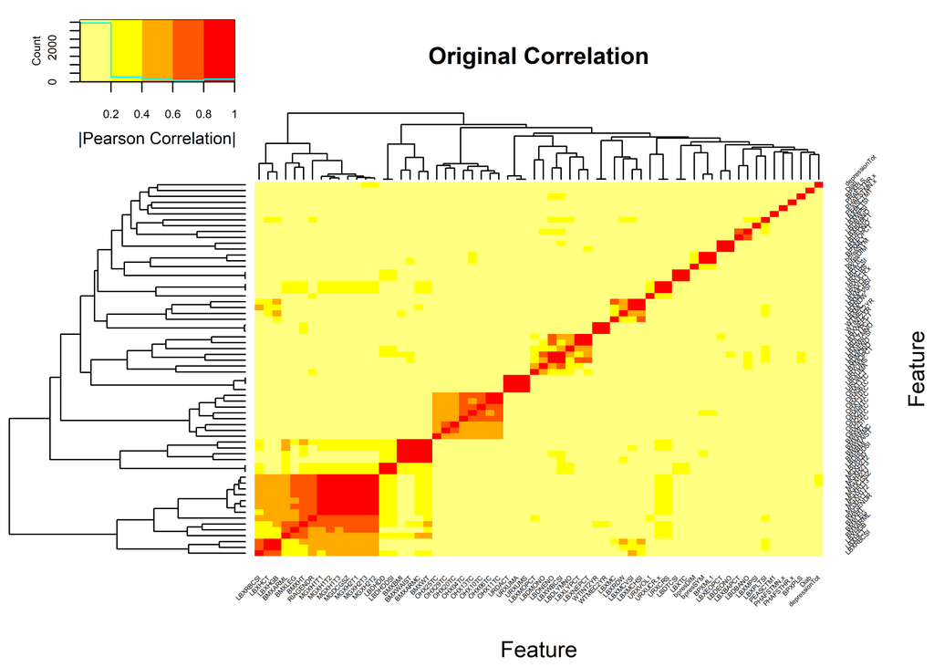

```r
par(op)
```

### 1.2.5 Decorrelating using ILAA

ILAA bootstrapped training and testing sets

```r
#trainage_DE <- ILAA(trainingset,thr=thro,Outcome=outcome,verbose=TRUE)
trainage_DE <- ILAA(trainingset,thr=thro,Outcome=outcome,verbose=TRUE,bootstrap=30)
```

fast | LM | URXUMA URXUCR.x PHAFSTMN.x WTINT2YR WTMEC2YR PEASCTM1 BPXPLS BPXML1 BMXWT 0.86885246 0.85245902 0.08196721 0.06557377 0.52459016 0.59016393

Included: 61 , Uni p: 0.002459016 , Base Size: 3 , Rcrit: 0.05038592

1 <R=0.835,thr=0.950>, Top: 7< 1 >Fa= 7,<|><>Tot Used: 18 , Added: 11 , Zero Std: 0 , Max Cor: 1.000

2 <R=0.774,thr=0.950>, Top: 3< 1 >Fa= 8,<|><>Tot Used: 19 , Added: 3 , Zero Std: 0 , Max Cor: 0.938

3 <R=0.740,thr=0.900>, Top: 4< 1 >Fa= 11,<|><>Tot Used: 26 , Added: 4 , Zero Std: 0 , Max Cor: 0.895

4 <R=0.700,thr=0.800>, Top: 4< 1 >Fa= 14,<|><>Tot Used: 34 , Added: 5 , Zero Std: 0 , Max Cor: 0.973

5 <R=0.681,thr=0.950>, Top: 2< 1 >Fa= 16,<|><>Tot Used: 36 , Added: 2 , Zero Std: 0 , Max Cor: 0.789

6 <R=0.651,thr=0.700>, Top: 6< 2 >Fa= 18,<|><>Tot Used: 40 , Added: 7 , Zero Std: 0 , Max Cor: 0.914

7 <R=0.625,thr=0.900>, Top: 1< 1 >Fa= 19,<|><>Tot Used: 40 , Added: 1 , Zero Std: 0 , Max Cor: 0.770

8 <R=0.607,thr=0.700>, Top: 4< 1 >Fa= 19,<|><>Tot Used: 40 , Added: 3 , Zero Std: 0 , Max Cor: 0.697

9 <R=0.591,thr=0.600>, Top: 8< 2 >Fa= 24,<|><>Tot Used: 49 , Added: 8 , Zero Std: 0 , Max Cor: 0.631

10 <R=0.545,thr=0.600>, Top: 1< 1 >Fa= 24,<|><>Tot Used: 49 , Added: 1 , Zero Std: 0 , Max Cor: 0.892

11 <R=0.571,thr=0.800>, Top: 1< 1 >Fa= 24,<|><>Tot Used: 49 , Added: 1 , Zero Std: 0 , Max Cor: 0.748

12 <R=0.556,thr=0.700>, Top: 1< 1 >Fa= 24,<|><>Tot Used: 49 , Added: 1 , Zero Std: 0 , Max Cor: 0.722

13 <R=0.554,thr=0.700>, Top: 1< 1 >Fa= 24,<|><>Tot Used: 49 , Added: 1 , Zero Std: 0 , Max Cor: 0.839

14 <R=0.566,thr=0.800>, Top: 1< 1 >Fa= 24,<|><>Tot Used: 49 , Added: 1 , Zero Std: 0 , Max Cor: 0.600

15 <R=0.540,thr=0.500>, Top: 8< 3 >Fa= 25,<|><>Tot Used: 51 , Added: 16 , Zero Std: 0 , Max Cor: 0.640

16 <R=0.524,thr=0.600>, Top: 2< 1 >Fa= 25,<|><>Tot Used: 51 , Added: 2 , Zero Std: 0 , Max Cor: 0.672

17 <R=0.508,thr=0.600>, Top: 1< 1 >Fa= 25,<|><>Tot Used: 51 , Added: 1 , Zero Std: 0 , Max Cor: 0.566

18 <R=0.482,thr=0.500>, Top: 3< 1 >Fa= 25,<|><>Tot Used: 51 , Added: 3 , Zero Std: 0 , Max Cor: 0.598

19 <R=0.483,thr=0.500>, Top: 1< 1 >Fa= 25,<|><>Tot Used: 51 , Added: 1 , Zero Std: 0 , Max Cor: 0.673

20 <R=0.491,thr=0.600>, Top: 1< 1 >Fa= 25,<|><>Tot Used: 51 , Added: 1 , Zero Std: 0 , Max Cor: 0.633

21 <R=0.484,thr=0.600>, Top: 1< 1 >Fa= 25,<|><>Tot Used: 51 , Added: 1 , Zero Std: 0 , Max Cor: 0.484

22 <R=0.454,thr=0.400>, Top: 7< 1 >Fa= 26,<|><>Tot Used: 53 , Added: 6 , Zero Std: 0 , Max Cor: 0.477

23 <R=0.459,thr=0.400>, Top: 1< 1 >Fa= 27,<|><>Tot Used: 53 , Added: 1 , Zero Std: 0 , Max Cor: 0.408

24 <R=0.408,thr=0.400>, Top: 1< 1 >Fa= 27,<|><>Tot Used: 53 , Added: 1 , Zero Std: 0 , Max Cor: 0.560

25 <R=0.560,thr=0.500>, Top: 1< 1 >Fa= 28,<|><>Tot Used: 53 , Added: 1 , Zero Std: 0 , Max Cor: 0.456

26 <R=0.456,thr=0.400>, Top: 1< 1 >Fa= 28,<|><>Tot Used: 53 , Added: 1 , Zero Std: 0 , Max Cor: 0.396

27 <R=0.396,thr=0.400>

[ 27 ], 0.4042229 Decor Dimension: 53 Nused: 53 . Cor to Base: 34 , ABase: 61 , Outcome Base: 0

bootstrapping .(r=0.39,w=1.00).{ 0 , 1 }(r=0.40,w=0.10).(r=0.40,w=1.00).(r=0.40,w=1.00).(r=0.39,w=1.00).(r=0.40,w=1.00).{ 1 , 0 }(r=0.40,w=0.10).(r=0.40,w=1.00).(r=0.40,w=1.00).(r=0.40,w=1.00).(r=0.40,w=1.00).(r=0.39,w=1.00).(r=0.40,w=1.00).(r=0.39,w=1.00).(r=0.39,w=1.00).(r=0.40,w=1.00).(r=0.39,w=1.00).(r=0.40,w=1.00).{ 0 , 1 }(r=0.40,w=0.10).{ 0 , 1 }(r=0.40,w=0.10).(r=0.39,w=1.00).(r=0.39,w=1.00).(r=0.40,w=1.00).(r=0.40,w=1.00).{ 0 , 1 }(r=0.40,w=0.10).(r=0.39,w=1.00).{ 0 , 2 }(r=0.40,w=0.10).{ 0 , 3 }(r=0.39,w=0.10).(r=0.40,w=1.00).(r=0.40,w=1.00)

RIDAGEYR PEASCTM1 BPXPLS OHX10TC bpresDIM LBXRDW 1 1 1 1 1 1

```r
testage_DE <- predictDecorrelate(trainage_DE,testingset)

attr(trainage_DE,"LatentVariables")
```

[1] “WTMEC2YR” “BMXWT” “BMXHT” “BMXLEG” “BMXARML” “BMXARMC” [7] “BMXWAIST” “MGXH1T1” “MGXH2T1” “MGXH1T2” “MGXH2T2” “MGXH1T3” [13] “MGXH2T3” “OHX04TC” “OHX11TC” “OHX13TC” “OHX20TC” “OHX25TC” [19] “OHX29TC” “bpresSYM” “URXUMS” “URXCRS” “URDACT” “LBXWBCSI” [25] “LBXLYPCT” “LBXMOPCT” “LBXEOPCT” “LBDLYMNO” “LBDMONO” “LBDNENO” [31] “LBDEONO” “LBDBANO” “LBXRBCSI” “LBXHGB” “LBXHCT” “LBXMCVSI” [37] “LBXMCHSI” “LBXMC” “LBXMPSI” “LBDHDDSI” “LBDTCSI”

```r
attr(trainage_DE,"useDeCorr")
```

[1] TRUE

### 1.2.6 The Formulas

Generating the formulas

```r
theLaFormulas <- getLatentCoefficients(trainage_DE)

theCharformulas <- attr(theLaFormulas,"LatentCharFormulas")
pander::pander(as.matrix(theCharformulas))
```

| **La_WTMEC2YR** | - (1.024)WTINT2YR + WTMEC2YR |
| --- | --- |
| **La_BMXWT** | + BMXWT - (2.758)BMXBMI - (0.326)MGDCGSZ |
| **La_BMXHT** | - (0.970)BMXWT + BMXHT + (2.674)BMXBMI |
| **La_BMXLEG** | - (0.131)BMXWT + (0.361)BMXBMI + BMXLEG - (0.262)BMXARML - (3.35e-03)MGDCGSZ |
| **La_BMXARML** | - (0.211)BMXWT + (0.573)BMXBMI + BMXARML - (5.35e-03)MGDCGSZ |
| **La_BMXARMC** | - (0.666)BMXBMI + BMXARMC - (0.066)MGDCGSZ |
| **La_BMXWAIST** | - (0.494)BMXWT - (0.843)BMXBMI + BMXWAIST + (0.161)MGDCGSZ |
| **La_MGXH1T1** | + MGXH1T1 - (0.439)MGDCGSZ |
| **La_MGXH2T1** | + MGXH2T1 + (0.611)MGXH1T3 - (0.762)MGDCGSZ |
| **La_MGXH1T2** | + MGXH1T2 - (0.536)MGXH1T3 - (0.211)MGDCGSZ |
| **La_MGXH2T2** | + MGXH2T2 + (0.596)MGXH1T3 - (0.779)MGDCGSZ |
| **La_MGXH1T3** | + MGXH1T3 - (0.486)MGDCGSZ |
| **La_MGXH2T3** | + (0.570)MGXH1T3 + MGXH2T3 - (0.771)MGDCGSZ |
| **La_OHX04TC** | + OHX04TC - (0.620)OHX13TC |
| **La_OHX11TC** | - (0.795)OHX06TC + OHX11TC |
| **La_OHX13TC** | - (0.708)OHX06TC + OHX13TC |
| **La_OHX20TC** | - (0.027)OHX06TC + OHX20TC - (0.590)OHX29TC |
| **La_OHX25TC** | - (0.491)OHX06TC + OHX25TC |
| **La_OHX29TC** | - (0.616)OHX06TC + OHX29TC |
| **La_bpresSYM** | - (0.911)BPXML1 + bpresSYM |
| **La_URXUMS** | - URXUMA + URXUMS |
| **La_URXCRS** | - (88.400)URXUCR.x + URXCRS |
| **La_URDACT** | - (0.870)URXUMA + URDACT |
| **La_LBXWBCSI** | + LBXWBCSI + (0.126)LBXNEPCT - (1.626)LBDNENO |
| **La_LBXLYPCT** | + LBXLYPCT + (0.849)LBXNEPCT |
| **La_LBXMOPCT** | + (0.989)LBXLYPCT + LBXMOPCT + (0.987)LBXNEPCT + (0.990)LBXEOPCT + (0.962)LBXBAPCT |
| **La_LBXEOPCT** | + (0.444)LBXLYPCT + (0.376)LBXNEPCT + LBXEOPCT |
| **La_LBDLYMNO** | - (0.946)LBXWBCSI - (0.074)LBXLYPCT - (0.075)LBXNEPCT - (0.061)LBXEOPCT + LBDLYMNO + (1.047)LBDNENO + (0.846)LBDEONO |
| **La_LBDMONO** | - (0.584)LBXWBCSI + (0.014)LBXLYPCT + (0.012)LBXNEPCT + (0.018)LBXEOPCT + (0.574)LBDLYMNO + LBDMONO + (0.569)LBDNENO + (0.487)LBDEONO |
| **La_LBDNENO** | - (0.128)LBXNEPCT + LBDNENO |
| **La_LBDEONO** | + (4.58e-03)LBXNEPCT - (0.072)LBXEOPCT - (0.036)LBDNENO + LBDEONO |
| **La_LBDBANO** | + (2.11e-03)LBXNEPCT - (0.100)LBXBAPCT - (0.016)LBDNENO + LBDBANO |
| **La_LBXRBCSI** | + LBXRBCSI + (0.332)LBXHGB - (0.221)LBXHCT + (0.103)LBXMCVSI - (0.150)LBXMCHSI |
| **La_LBXHGB** | + LBXHGB - (0.354)LBXHCT |
| **La_LBXHCT** | - (0.083)MGDCGSZ + LBXHCT |
| **La_LBXMCVSI** | + (5.976)LBXHGB - (2.025)LBXHCT + LBXMCVSI - (2.867)LBXMCHSI |
| **La_LBXMCHSI** | - (3.536)LBXHGB + (1.251)LBXHCT + LBXMCHSI |
| **La_LBXMC** | + (1.441)LBXRBCSI - (0.897)LBXHGB + (0.136)LBXHCT + (0.309)LBXMCVSI - (0.708)LBXMCHSI + LBXMC |
| **La_LBXMPSI** | + (6.33e-03)LBXPLTSI + LBXMPSI |
| **La_LBDHDDSI** | - (0.026)LBDHDD + LBDHDDSI |
| **La_LBDTCSI** | - (0.026)LBXTC + LBDTCSI |

### 1.2.7 Formulas Network

Displaying the features associations

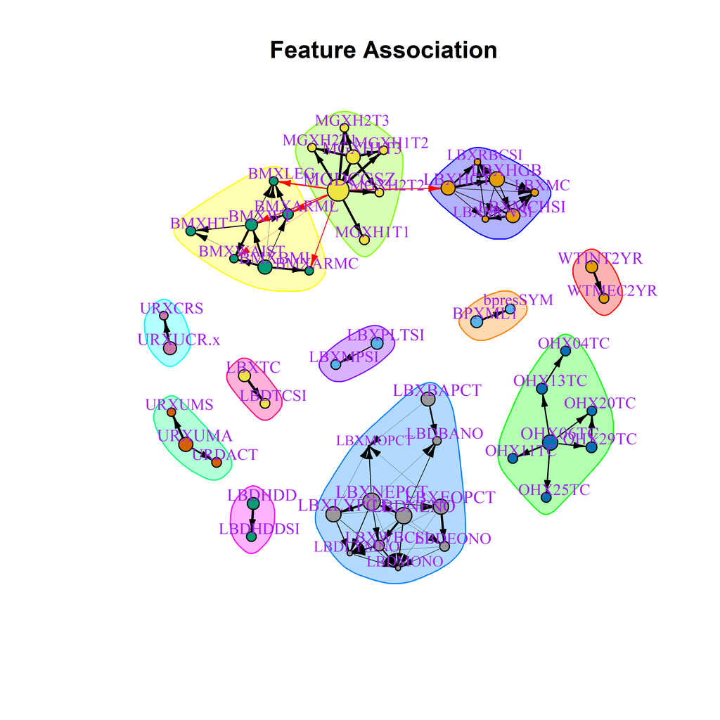

```r
par(op)

  transform <- attr(trainage_DE,"UPLTM") != 0
  colnames(transform) <- str_remove_all(colnames(transform),"La_")
  transform <- abs(transform*cor(trainingset[,rownames(transform)])) # The weights are proportional to the observed correlation


  VertexSize <- attr(trainage_DE,"fscore") # The size depends on the variable independence relevance (fscore)
  names(VertexSize) <- str_remove_all(names(VertexSize),"La_")
  VertexSize <- 0.5+9.5*(VertexSize-min(VertexSize))/(max(VertexSize)-min(VertexSize)) # Normalization
  VertexSize <- VertexSize[colnames(transform)]
  gr <- graph_from_adjacency_matrix(transform,mode = "directed",diag = FALSE,weighted=TRUE)
  gr$layout <- layout_with_fr

  fc <- cluster_optimal(gr)
  plot(fc, gr,
       edge.width = 2*E(gr)$weight,
       vertex.size=VertexSize,
       edge.arrow.size=0.5,
       edge.arrow.width=0.75,
       vertex.label.color="purple",
#       vertex.label.cex=0.85,
#       vertex.label.dist=1.2,
       vertex.label.cex=(0.70 + 0.025*VertexSize),
       vertex.label.dist=(0.5 + 0.05*VertexSize),


       main="Feature Association")
```

```r
par(op)

      varratios <- attr(trainage_DE,"VarRatio")
      names(varratios) <- str_remove_all(names(varratios),"La_")
      fscores <- attr(trainage_DE,"fscore")
      names(fscores) <- str_remove_all(names(fscores),"La_")
      clustable <- as.data.frame(cbind(Variable=fc$names,
                                       Formula=as.character(theCharformulas[paste("La_",fc$names,sep="")]),
                                       Cluster=fc$membership,
                                       ResidualVariance=round(varratios[fc$names],3),
                                       Fscore=round(fscores[fc$names],3)
                                       )
                                 )
      rownames(clustable) <- str_replace_all(rownames(clustable),"__","_")
      clustable$Variable <- NULL
      clustable$Cluster <- as.integer(clustable$Cluster)
      clustable$ResidualVariance <- as.numeric(clustable$ResidualVariance)
      clustable$Fscore <- as.numeric(clustable$Fscore)
      clustable <- clustable[order(-clustable$Fscore),]
      clustable <- clustable[order(-clustable$ResidualVariance),]
      clustable <- clustable[order(clustable$Cluster),]

pander::pander(as.matrix(clustable))
```

|  | Formula | Cluster | ResidualVariance | Fscore |
| --- | --- | --- | --- | --- |
| **WTINT2YR** | NA | 1 | 1.000 | 1.000 |
| **WTMEC2YR** | - (1.024)WTINT2YR + WTMEC2YR | 1 | 0.002 | -1.000 |
| **BPXML1** | NA | 2 | 1.000 | 1.000 |
| **bpresSYM** | - (0.911)BPXML1 + bpresSYM | 2 | 0.215 | -1.000 |
| **BMXBMI** | NA | 3 | 1.000 | 3.085 |
| **BMXLEG** | - (0.131)BMXWT + (0.361)BMXBMI + BMXLEG - (0.262)BMXARML - (3.35e-03)MGDCGSZ | 3 | 0.449 | -1.915 |
| **BMXARML** | - (0.211)BMXWT + (0.573)BMXBMI + BMXARML - (5.35e-03)MGDCGSZ | 3 | 0.386 | -0.170 |
| **BMXARMC** | - (0.666)BMXBMI + BMXARMC - (0.066)MGDCGSZ | 3 | 0.148 | -2.000 |
| **BMXWAIST** | - (0.494)BMXWT - (0.843)BMXBMI + BMXWAIST + (0.161)MGDCGSZ | 3 | 0.127 | -2.000 |
| **BMXWT** | + BMXWT - (2.758)BMXBMI - (0.326)MGDCGSZ | 3 | 0.113 | 1.000 |
| **BMXHT** | - (0.970)BMXWT + BMXHT + (2.674)BMXBMI | 3 | 0.053 | -1.000 |
| **MGDCGSZ** | NA | 4 | 1.000 | 10.000 |
| **MGXH1T1** | + MGXH1T1 - (0.439)MGDCGSZ | 4 | 0.119 | -1.000 |
| **MGXH2T1** | + MGXH2T1 + (0.611)MGXH1T3 - (0.762)MGDCGSZ | 4 | 0.065 | -2.000 |
| **MGXH1T3** | + MGXH1T3 - (0.486)MGDCGSZ | 4 | 0.058 | 3.000 |
| **MGXH1T2** | + MGXH1T2 - (0.536)MGXH1T3 - (0.211)MGDCGSZ | 4 | 0.057 | -2.000 |
| **MGXH2T2** | + MGXH2T2 + (0.596)MGXH1T3 - (0.779)MGDCGSZ | 4 | 0.042 | -2.000 |
| **MGXH2T3** | + (0.570)MGXH1T3 + MGXH2T3 - (0.771)MGDCGSZ | 4 | 0.042 | -2.000 |
| **OHX06TC** | NA | 5 | 1.000 | 4.085 |
| **OHX29TC** | - (0.616)OHX06TC + OHX29TC | 5 | 0.688 | 0.000 |
| **OHX25TC** | - (0.491)OHX06TC + OHX25TC | 5 | 0.673 | -1.000 |
| **OHX13TC** | - (0.708)OHX06TC + OHX13TC | 5 | 0.672 | 0.000 |
| **OHX20TC** | - (0.027)OHX06TC + OHX20TC - (0.590)OHX29TC | 5 | 0.615 | -1.085 |
| **OHX04TC** | + OHX04TC - (0.620)OHX13TC | 5 | 0.606 | -1.000 |
| **OHX11TC** | - (0.795)OHX06TC + OHX11TC | 5 | 0.392 | -1.000 |
| **URXUMA** | NA | 6 | 1.000 | 3.000 |
| **URDACT** | - (0.870)URXUMA + URDACT | 6 | 0.379 | -1.000 |
| **URXUMS** | - URXUMA + URXUMS | 6 | 0.000 | -1.996 |
| **URXUCR.x** | NA | 7 | 1.000 | 2.000 |
| **URXCRS** | - (88.400)URXUCR.x + URXCRS | 7 | 0.000 | -2.000 |
| **LBXNEPCT** | NA | 8 | 1.000 | 6.040 |
| **LBXBAPCT** | NA | 8 | 1.000 | 2.834 |
| **LBXEOPCT** | + (0.444)LBXLYPCT + (0.376)LBXNEPCT + LBXEOPCT | 8 | 0.566 | 3.996 |
| **LBDNENO** | - (0.128)LBXNEPCT + LBDNENO | 8 | 0.530 | 4.996 |
| **LBDBANO** | + (2.11e-03)LBXNEPCT - (0.100)LBXBAPCT - (0.016)LBDNENO + LBDBANO | 8 | 0.405 | -2.000 |
| **LBDEONO** | + (4.58e-03)LBXNEPCT - (0.072)LBXEOPCT - (0.036)LBDNENO + LBDEONO | 8 | 0.135 | -1.000 |
| **LBXWBCSI** | + LBXWBCSI + (0.126)LBXNEPCT - (1.626)LBDNENO | 8 | 0.131 | -0.040 |
| **LBXLYPCT** | + LBXLYPCT + (0.849)LBXNEPCT | 8 | 0.129 | 4.000 |
| **LBDMONO** | - (0.584)LBXWBCSI + (0.014)LBXLYPCT + (0.012)LBXNEPCT + (0.018)LBXEOPCT + (0.574)LBDLYMNO + LBDMONO + (0.569)LBDNENO + (0.487)LBDEONO | 8 | 0.108 | -5.165 |
| **LBDLYMNO** | - (0.946)LBXWBCSI - (0.074)LBXLYPCT - (0.075)LBXNEPCT - (0.061)LBXEOPCT + LBDLYMNO + (1.047)LBDNENO + (0.846)LBDEONO | 8 | 0.006 | -4.976 |
| **LBXMOPCT** | + (0.989)LBXLYPCT + LBXMOPCT + (0.987)LBXNEPCT + (0.990)LBXEOPCT + (0.962)LBXBAPCT | 8 | 0.002 | -9.036 |
| **LBXHCT** | - (0.083)MGDCGSZ + LBXHCT | 9 | 0.797 | 3.000 |
| **LBXMCHSI** | - (3.536)LBXHGB + (1.251)LBXHCT + LBXMCHSI | 9 | 0.658 | 2.964 |
| **LBXHGB** | + LBXHGB - (0.354)LBXHCT | 9 | 0.068 | 3.964 |
| **LBXMC** | + (1.441)LBXRBCSI - (0.897)LBXHGB + (0.136)LBXHCT + (0.309)LBXMCVSI - (0.708)LBXMCHSI + LBXMC | 9 | 0.016 | -3.000 |
| **LBXRBCSI** | + LBXRBCSI + (0.332)LBXHGB - (0.221)LBXHCT + (0.103)LBXMCVSI - (0.150)LBXMCHSI | 9 | 0.010 | -4.000 |
| **LBXMCVSI** | + (5.976)LBXHGB - (2.025)LBXHCT + LBXMCVSI - (2.867)LBXMCHSI | 9 | 0.007 | -3.919 |
| **LBXPLTSI** | NA | 10 | 1.000 | 1.000 |
| **LBXMPSI** | + (6.33e-03)LBXPLTSI + LBXMPSI | 10 | 0.834 | -1.000 |
| **LBDHDD** | NA | 11 | 1.000 | 1.000 |
| **LBDHDDSI** | - (0.026)LBDHDD + LBDHDDSI | 11 | 0.000 | -1.000 |
| **LBXTC** | NA | 12 | 1.000 | 1.000 |
| **LBDTCSI** | - (0.026)LBXTC + LBDTCSI | 12 | 0.000 | -1.000 |

### 1.2.8 Correlation Matrix of the Data

The heat map of the ILAA transformed data

```r
par(op)

varlistDe <- colnames(trainage_DE)
varlistDe <- varlistDe[varlistDe != outcome]

  par(cex=0.6,cex.main=0.85,cex.axis=0.7)

# Training
  cormat <- cor(trainage_DE[,varlistDe],method="pearson")
  cormat[is.na(cormat)] <- 0
  gplots::heatmap.2(abs(cormat),
                    trace = "none",
                    mar = c(5,5),
                    col=rev(heat.colors(5)),
                    main = "Training: After ILAA Correlation",
                    cexRow = cexheat,
                    cexCol = cexheat,
                     srtCol=45,
                     srtRow=45,
                    key.title=NA,
                    key.xlab="|Pearson Correlation|",
                    xlab="Feature", ylab="Feature")
  diag(cormat) <- 0
  pander::pander(max(abs(cormat)))
```

*0.726*

```r
  par(op)
```

[figure not shown]

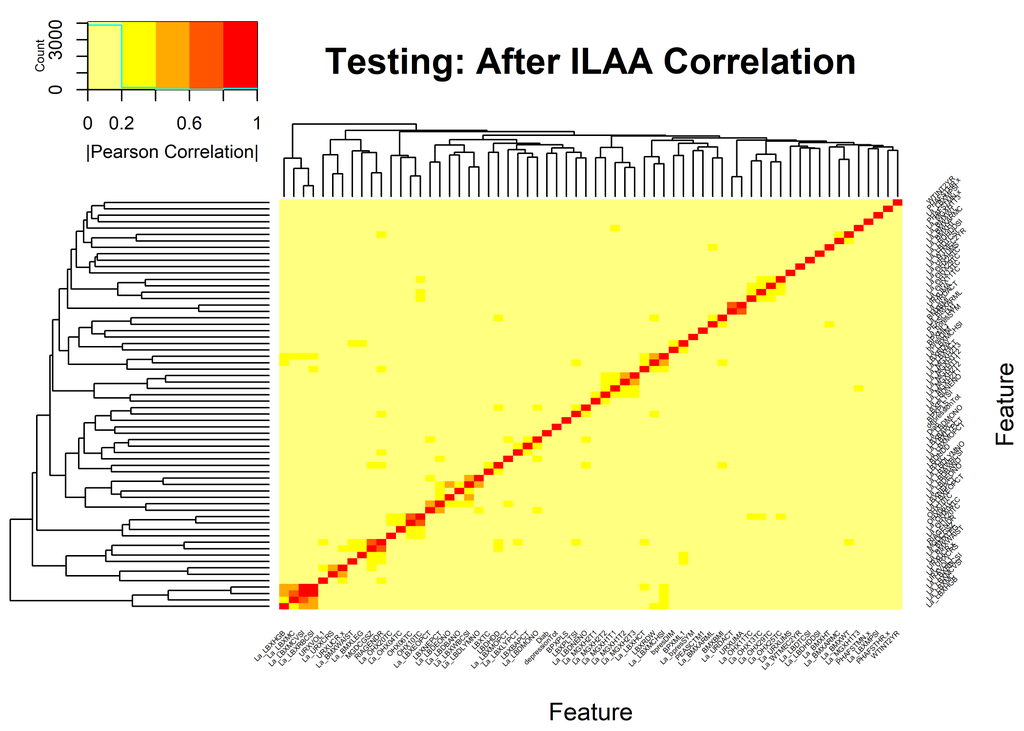

```r
# Testing

  cormat <- cor(testage_DE[,varlistDe],method="pearson")
  cormat[is.na(cormat)] <- 0
  gplots::heatmap.2(abs(cormat),
                    trace = "none",
                    mar = c(5,5),
                    col=rev(heat.colors(5)),
                    main = "Testing: After ILAA Correlation",
                    cexRow = cexheat,
                    cexCol = cexheat,
                     srtCol=45,
                     srtRow=45,
                    key.title=NA,
                    key.xlab="|Pearson Correlation|",
                    xlab="Feature", ylab="Feature")
```

```r
  diag(cormat) <- 0
  pander::pander(max(abs(cormat)))
```

*0.893*

```r
  par(op)
```

### 1.2.9 Modeling

#### 1.2.9.1 Modeling outcome using raw set

```r
outcomeModel <- LASSO_1SE(formula(paste(outcome,"~.")),trainingset);
predOutcome <- predict(outcomeModel,testingset)
pander::pander(as.matrix(outcomeModel$coef))
```

| **(Intercept)** | 7.07e+00 |
| --- | --- |
| **WTMEC2YR** | -3.17e-06 |
| **PEASCTM1** | 1.24e-03 |
| **BPXPLS** | -1.54e-01 |
| **BPXML1** | 2.26e-01 |
| **BMXWT** | -1.28e-01 |
| **BMXBMI** | -7.63e-01 |
| **BMXLEG** | -8.77e-01 |
| **BMXARML** | 7.78e-01 |
| **BMXARMC** | 9.10e-02 |
| **BMXWAIST** | 5.98e-01 |
| **MGXH1T1** | -3.63e-02 |
| **MGXH1T2** | 1.37e-01 |
| **MGXH2T2** | 7.40e-02 |
| **MGXH1T3** | 1.20e-01 |
| **MGXH2T3** | 2.01e-01 |
| **MGDCGSZ** | -4.71e-01 |
| **OHX04TC** | 1.20e+00 |
| **OHX06TC** | 6.41e-01 |
| **OHX10TC** | 3.58e-01 |
| **OHX11TC** | -4.16e-01 |
| **OHX13TC** | 1.17e+00 |
| **OHX20TC** | 1.39e+00 |
| **OHX25TC** | 4.01e-01 |
| **OHX29TC** | 4.97e-01 |
| **bpresDIM** | -4.91e-02 |
| **bpresSYM** | 5.36e-02 |
| **URXUMA** | 1.79e-04 |
| **URXUMS** | 3.74e-17 |
| **URXUCR.x** | -1.63e-02 |
| **URDACT** | -2.56e-03 |
| **LBXLYPCT** | -2.27e-01 |
| **LBXMOPCT** | 1.29e-01 |
| **LBXEOPCT** | -1.98e-01 |
| **LBXBAPCT** | 3.00e+00 |
| **LBDLYMNO** | 4.35e-01 |
| **LBDMONO** | 1.81e+00 |
| **LBDNENO** | -1.19e+00 |
| **LBDEONO** | 2.71e+00 |
| **LBXHGB** | -6.00e-01 |
| **LBXMCVSI** | 3.87e-01 |
| **LBXMC** | -5.41e-01 |
| **LBXRDW** | 9.80e-01 |
| **LBXPLTSI** | -2.60e-02 |
| **LBXMPSI** | -1.07e+00 |
| **PHAFSTHR.x** | -3.55e-02 |
| **PHAFSTMN.x** | -3.51e-04 |
| **LBDHDDSI** | 3.39e+00 |
| **LBXTC** | 2.45e-02 |
| **LBDTCSI** | 6.08e-02 |
| **URXVOL1** | -1.22e-02 |
| **depressionTot** | -7.20e-01 |
| **RIAGENDR** | -6.58e+00 |
| **Diab** | -1.36e+00 |

#### 1.2.9.2 Modeling outcome using decorrelated set

```r
outcomeModel_DE <- LASSO_1SE(formula(paste(outcome,"~.")),trainage_DE);
predOutcome_DE <- predict(outcomeModel_DE,testage_DE)

pander::pander(as.matrix(outcomeModel_DE$coef),caption="ILAA Coef")
```

ILAA Coef

| **(Intercept)** | 8.20e+00 |
| --- | --- |
| **La_WTMEC2YR** | -6.67e-04 |
| **PEASCTM1** | 2.33e-04 |
| **BPXPLS** | -1.52e-01 |
| **BPXML1** | 2.75e-01 |
| **La_BMXWT** | 1.38e-01 |
| **BMXBMI** | 1.41e-01 |
| **La_BMXLEG** | -7.89e-01 |
| **La_BMXARML** | 6.14e-01 |
| **La_BMXARMC** | 7.38e-02 |
| **La_BMXWAIST** | 6.37e-01 |
| **La_MGXH2T1** | 3.91e-02 |
| **La_MGXH1T2** | 1.13e-01 |
| **La_MGXH2T2** | 2.14e-01 |
| **La_MGXH1T3** | 4.42e-02 |
| **La_MGXH2T3** | 3.35e-01 |
| **MGDCGSZ** | -2.38e-01 |
| **La_OHX04TC** | 9.03e-01 |
| **OHX06TC** | 2.46e+00 |
| **OHX10TC** | 5.74e-01 |
| **La_OHX13TC** | 1.55e+00 |
| **La_OHX20TC** | 1.02e+00 |
| **La_OHX25TC** | 1.46e-01 |
| **La_OHX29TC** | 1.02e+00 |
| **bpresDIM** | -1.94e-02 |
| **La_bpresSYM** | 3.23e-03 |
| **URXUMA** | -5.82e-05 |
| **URXUCR.x** | -8.00e-03 |
| **La_URXCRS** | -1.54e+11 |
| **La_URDACT** | -9.97e-04 |
| **La_LBXWBCSI** | 3.62e-01 |
| **La_LBXLYPCT** | -3.41e-01 |
| **La_LBXMOPCT** | -1.33e-01 |
| **La_LBXEOPCT** | -2.22e-01 |
| **LBXBAPCT** | 2.00e+00 |
| **La_LBDNENO** | -6.64e-01 |
| **La_LBDEONO** | 3.24e+00 |
| **La_LBXHCT** | -3.40e-02 |
| **La_LBXMCHSI** | 9.37e-01 |
| **LBXRDW** | 9.70e-01 |
| **LBXPLTSI** | -1.61e-02 |
| **La_LBXMPSI** | -8.58e-01 |
| **LBDHDD** | 6.12e-02 |
| **LBXTC** | 1.53e-02 |
| **URXVOL1** | -6.22e-03 |
| **depressionTot** | -3.61e-01 |
| **RIAGENDR** | -3.18e+00 |
| **Diab** | -6.98e-01 |

```r
obsCoef <- getObservedCoef(trainage_DE,outcomeModel_DE)
pander::pander(as.matrix(obsCoef$coef),caption="ILAA Modeling")
```

ILAA Modeling

| **(Intercept)** | 8.20e+00 |
| --- | --- |
| **PEASCTM1** | 2.33e-04 |
| **BPXPLS** | -1.52e-01 |
| **OHX10TC** | 5.74e-01 |
| **bpresDIM** | -1.94e-02 |
| **LBXRDW** | 9.70e-01 |
| **URXVOL1** | -6.22e-03 |
| **depressionTot** | -3.61e-01 |
| **RIAGENDR** | -3.18e+00 |
| **Diab** | -6.98e-01 |
| **WTINT2YR** | 6.83e-04 |
| **WTMEC2YR** | -6.67e-04 |
| **BPXML1** | 2.72e-01 |
| **BMXWT** | -2.04e-01 |
| **BMXBMI** | -7.58e-01 |
| **BMXLEG** | -7.89e-01 |
| **BMXARML** | 8.21e-01 |
| **BMXARMC** | 7.38e-02 |
| **BMXWAIST** | 6.37e-01 |
| **MGXH2T1** | 3.91e-02 |
| **MGXH1T2** | 1.13e-01 |
| **MGXH2T2** | 2.14e-01 |
| **MGXH1T3** | 3.26e-01 |
| **MGXH2T3** | 3.35e-01 |
| **MGDCGSZ** | -6.82e-01 |
| **OHX04TC** | 9.03e-01 |
| **OHX06TC** | 6.34e-01 |
| **OHX13TC** | 9.91e-01 |
| **OHX20TC** | 1.02e+00 |
| **OHX25TC** | 1.46e-01 |
| **OHX29TC** | 4.24e-01 |
| **bpresSYM** | 3.23e-03 |
| **URXUMA** | 8.09e-04 |
| **URXUCR.x** | 1.36e+13 |
| **URXCRS** | -1.54e+11 |
| **URDACT** | -9.97e-04 |
| **LBXWBCSI** | 3.62e-01 |
| **LBXLYPCT** | -5.71e-01 |
| **LBXMOPCT** | -1.33e-01 |
| **LBXNEPCT** | -3.59e-01 |
| **LBXEOPCT** | -5.89e-01 |
| **LBXBAPCT** | 1.87e+00 |
| **LBDNENO** | -1.37e+00 |
| **LBDEONO** | 3.24e+00 |
| **LBXHGB** | -3.31e+00 |
| **LBXHCT** | 1.14e+00 |
| **LBXMCHSI** | 9.37e-01 |
| **LBXPLTSI** | -2.16e-02 |
| **LBXMPSI** | -8.58e-01 |
| **LBDHDD** | 6.12e-02 |
| **LBXTC** | 1.53e-02 |

```r
pander::pander(cor.test(predOutcome,testingset[,outcome]),caption="Raw Model")
```

Raw Model

| Test statistic | df | P value | Alternative hypothesis | cor |
| --- | --- | --- | --- | --- |
| 41.3 | 1037 | 4.01e-221 * * * | two.sided | 0.788 |

```r
pander::pander(cor.test(predOutcome_DE,testage_DE[,outcome]),caption="ILAA-based Model")
```

ILAA-based Model

| Test statistic | df | P value | Alternative hypothesis | cor |
| --- | --- | --- | --- | --- |
| 40.6 | 1037 | 1.03e-216 * * * | two.sided | 0.784 |

#### 1.2.9.3 Univariate t-test

```r
rawunittvalues <- apply(as.matrix(testingset[,names(outcomeModel$coef)[-1]]),2,tvals,testingset[,outcome])
names(rawunittvalues) <- names(outcomeModel$coef)[-1]

deunittvalues <- apply(testage_DE[,names(outcomeModel_DE$coef)[-1]],2,tvals,testingset[,outcome])
```

#### 1.2.9.4 Comparing summaries

```r
psig <- 0.1/(ncol(testingset)-1)
lmod <- lm(paste(outcome,"~."),testingset[,c(outcome,names(outcomeModel$coef)[-1])])
try(vifx <-vif(lm(paste(outcome,"~."),testingset[,c(outcome,names(outcomeModel$coef)[-1])])))
```

Error in vif.default(lm(paste(outcome, “~.”), testingset[, c(outcome, : there are aliased coefficients in the model

```r
sm <- summary(lmod)
if (length(lmod$coef)>10)
{
  sm$coefficients[1,4] <- 1.0
  gcoef <- lmod$coef[sm$coefficients[,4]<psig]
  lmod <- lm(paste(outcome,"~."),testingset[,c(outcome,names(gcoef))])
  try(vifx <-vif(lm(paste(outcome,"~."),testingset[,c(outcome,names(gcoef))])))
}



sm <- summary(lmod)
smcoef <- as.data.frame(sm$coefficients)
smcoef <- smcoef[order(-abs(smcoef[,3])),]
smcoef$Uni_t_values <- rawunittvalues[rownames(smcoef)]
if (!inherits(vif,"try-error")) smcoef$vif <-vifx[rownames(smcoef)]
smcoef <- smcoef[!is.na(smcoef$Uni_t_values),]
if (nrow(smcoef)>10) smcoef <- smcoef[smcoef[,4]<psig,]

pander::pander(smcoef)
```

|  | Estimate | Std. Error | t value | Pr(>\|t\|) | Uni_t_values | vif |
| --- | --- | --- | --- | --- | --- | --- |
| **BPXML1** | 0.4019 | 0.02524 | 15.93 | 3.45e-51 | 17.362 | 1.09 |
| **BMXARML** | 1.6152 | 0.22316 | 7.24 | 8.90e-13 | -0.334 | 2.52 |
| **BMXLEG** | -1.0315 | 0.16499 | -6.25 | 5.95e-10 | -10.171 | 2.48 |
| **MGDCGSZ** | -0.4653 | 0.07660 | -6.07 | 1.75e-09 | -10.525 | 17.56 |
| **BPXPLS** | -0.2167 | 0.03590 | -6.04 | 2.19e-09 | -5.817 | 1.09 |
| **LBXEOPCT** | 2.0961 | 0.41926 | 5.00 | 6.75e-07 | 3.605 | 5.76 |
| **LBXPLTSI** | -0.0351 | 0.00703 | -5.00 | 6.84e-07 | -5.049 | 1.17 |
| **LBDEONO** | -18.7655 | 4.79578 | -3.91 | 9.72e-05 | 1.585 | 5.79 |
| **BMXWAIST** | 0.1054 | 0.02972 | 3.55 | 4.07e-04 | 5.222 | 1.44 |

```r
pander::pander(t(c(R2=sm$r.squared,adj_R2=sm$adj.r.squared)))
```

| R2 | adj_R2 |
| --- | --- |
| 0.451 | 0.444 |

```r
pander::pander(c(numvar=nrow(smcoef)))
```

| numvar |
| --- |
| 9 |

```r
lmod_DE <- lm(paste(outcome,"~."),testage_DE[,c(outcome,names(outcomeModel_DE$coef)[-1])])
try(vifx <-vif(lm(paste(outcome,"~."),testage_DE[,c(outcome,names(outcomeModel_DE$coef)[-1])])))

sm <- summary(lmod_DE)
if (length(lmod_DE$coef)>10)
{
  sm$coefficients[1,4] <- 1.0
  gcoef <- lmod_DE$coef[sm$coefficients[,4]<psig]
  lmod_DE <- lm(paste(outcome,"~."),testage_DE[,c(outcome,names(gcoef))])
  try(vifx <-vif(lm(paste(outcome,"~."),testage_DE[,c(outcome,names(gcoef))])))
}

sm <- summary(lmod_DE)
lacoef <- as.data.frame(sm$coefficients)
lacoef <- lacoef[order(-abs(lacoef[,3])),]
lacoef$Uni_t_values <- deunittvalues[rownames(lacoef)]
if (!inherits(vif,"try-error")) lacoef$vif <-vifx[rownames(lacoef)]
lacoef <- lacoef[!is.na(lacoef$Uni_t_values),]
if (nrow(lacoef)>10) lacoef <- lacoef[lacoef[,4]<psig,]

lacoef$formula <- theCharformulas[rownames(lacoef)]
lacoef$VarRatio <- varratios[str_remove_all(rownames(lacoef),"La_")]

pander::pander(lacoef)
```

|  | Estimate | Std. Error | t value | Pr(>\|t\|) | Uni_t_values | vif | formula | VarRatio |
| --- | --- | --- | --- | --- | --- | --- | --- | --- |
| **MGDCGSZ** | -0.38293 | 0.025362 | -15.10 | 1.22e-46 | -10.525 | 2.52 | NA | 1.00000 |
| **BPXML1** | 0.31338 | 0.022831 | 13.73 | 1.79e-39 | 17.362 | 1.16 | NA | 1.00000 |
| **La_BMXWAIST** | 0.61575 | 0.066149 | 9.31 | 7.69e-20 | 10.639 | 1.29 | - (0.494)BMXWT - (0.843)BMXBMI + BMXWAIST + (0.161)MGDCGSZ | 0.12688 |
| **RIAGENDR** | -8.59846 | 1.188543 | -7.23 | 9.17e-13 | -0.461 | 2.88 | NA | 1.00000 |
| **La_BMXLEG** | -1.00137 | 0.158929 | -6.30 | 4.40e-10 | -12.378 | 1.38 | - (0.131)BMXWT + (0.361)BMXBMI + BMXLEG - (0.262)BMXARML - (3.35e-03)MGDCGSZ | 0.44924 |
| **La_LBXLYPCT** | -0.73265 | 0.120975 | -6.06 | 1.96e-09 | -8.068 | 1.12 | + LBXLYPCT + (0.849)LBXNEPCT | 0.12936 |
| **La_LBXHCT** | -0.61958 | 0.110859 | -5.59 | 2.93e-08 | 1.479 | 1.32 | - (0.083)MGDCGSZ + LBXHCT | 0.79676 |
| **La_LBXMCHSI** | 0.93682 | 0.180417 | 5.19 | 2.50e-07 | 6.224 | 1.20 | - (3.536)LBXHGB + (1.251)LBXHCT + LBXMCHSI | 0.65817 |
| **BPXPLS** | -0.15627 | 0.031604 | -4.94 | 8.92e-07 | -5.817 | 1.11 | NA | 1.00000 |
| **La_LBDNENO** | -1.46373 | 0.317306 | -4.61 | 4.47e-06 | -5.686 | 1.24 | - (0.128)LBXNEPCT + LBDNENO | 0.53015 |
| **La_OHX20TC** | 2.54153 | 0.554961 | 4.58 | 5.23e-06 | 6.775 | 1.04 | - (0.027)OHX06TC + OHX20TC - (0.590)OHX29TC | 0.61528 |
| **La_BMXARML** | 0.96704 | 0.211850 | 4.56 | 5.61e-06 | 5.755 | 1.16 | - (0.211)BMXWT + (0.573)BMXBMI + BMXARML - (5.35e-03)MGDCGSZ | 0.38638 |
| **La_WTMEC2YR** | -0.00102 | 0.000248 | -4.13 | 3.85e-05 | -4.507 | 1.02 | - (1.024)WTINT2YR + WTMEC2YR | 0.00232 |
| **La_LBXMPSI** | -1.48764 | 0.416346 | -3.57 | 3.69e-04 | -4.357 | 1.07 | + (6.33e-03)LBXPLTSI + LBXMPSI | 0.83438 |
| **LBXTC** | 0.03232 | 0.009192 | 3.52 | 4.58e-04 | 3.650 | 1.11 | NA | 1.00000 |
| **LBXPLTSI** | -0.02211 | 0.006418 | -3.44 | 5.95e-04 | -5.049 | 1.28 | NA | 1.00000 |

```r
pander::pander(t(c(R2=sm$r.squared,adj_R2=sm$adj.r.squared)))
```

| R2 | adj_R2 |
| --- | --- |
| 0.582 | 0.575 |

```r
pander::pander(c(numvar=nrow(lacoef)))
```

| numvar |
| --- |
| 16 |

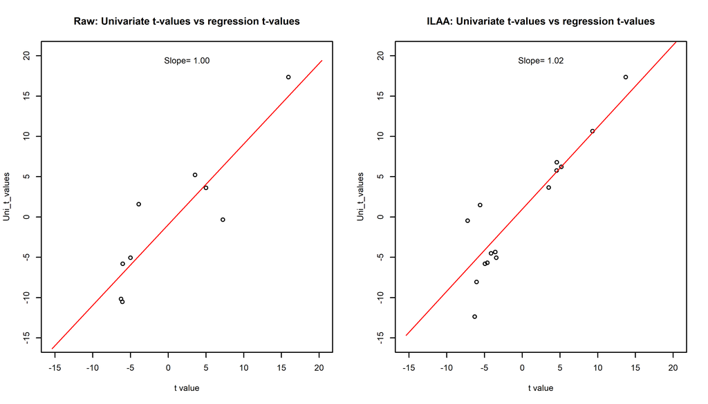

```r
xvals <-c(min(c(deunittvalues,rawunittvalues))-3,max(c(deunittvalues,rawunittvalues))+3)

par(mfrow=c(1,2),cex=0.5)

plot(smcoef[,c(3,5)],
     main="Raw: Univariate t-values vs regression t-values",
     xlim=xvals,
     ylim=xvals
     )

lmtvals <- lm(smcoef[,5]~smcoef[,3])
pred <- lmtvals$coefficients[1] + lmtvals$coefficients[2] * xvals
lines(x=xvals,y=pred,col="red")
text(xvals[1]+(xvals[2]-xvals[1])/2,xvals[2]-1,sprintf("Slope= %.2f",lmtvals$coefficients[2]))


plot(lacoef[-1,c(3,5)],
     main="ILAA: Univariate t-values vs regression t-values",
     xlim=xvals,
     ylim=xvals
     )

lmtvals <- lm(lacoef[,5]~lacoef[,3])
pred <- lmtvals$coefficients[1] + lmtvals$coefficients[2] * xvals
lines(x=xvals,y=pred,col="red")
text(xvals[1]+(xvals[2]-xvals[1])/2,xvals[2]-1,sprintf("Slope= %.2f",lmtvals$coefficients[2]))
```

```r
#pander::pander(summary(lmtvals))


pander::pander(cor.test(smcoef[,3],smcoef[,5]))
```

Pearson’s product-moment correlation: `smcoef[, 3]` and `smcoef[, 5]`

| Test statistic | df | P value | Alternative hypothesis | cor |
| --- | --- | --- | --- | --- |
| 5.34 | 7 | 0.00108 * * | two.sided | 0.896 |

```r
pander::pander(cor.test(lacoef[,3],lacoef[,5]))
```

Pearson’s product-moment correlation: `lacoef[, 3]` and `lacoef[, 5]`

| Test statistic | df | P value | Alternative hypothesis | cor |
| --- | --- | --- | --- | --- |
| 8.28 | 14 | 9.15e-07 * * * | two.sided | 0.911 |

```r
par(op)
```

#### 1.2.9.5 Ploting predictions

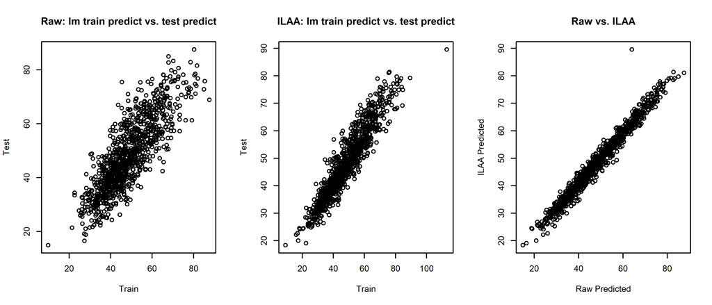

```r
par(mfrow=c(1,3),cex=0.5)
plot(lmod$fitted.values,predOutcome,main="Raw: lm train predict vs. test predict",xlab="Train",ylab="Test")
plot(lmod_DE$fitted.values,predOutcome_DE,main="ILAA: lm train predict vs. test predict",xlab="Train",ylab="Test")

plot(predOutcome,predOutcome_DE,xlab="Raw Predicted",ylab="ILAA Predicted",main="Raw vs. ILAA")
```

```r
par(op)
```

### 1.2.10 CV

#### 1.2.10.1 test Correlations

```r
par(op)
corresults <- CV_IDeA(dataframe,outcome,loops=loops)
```

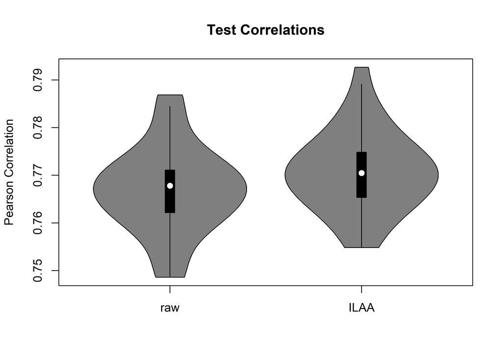

```r
mintvals <- min(c(min(corresults$rawtValues),min(corresults$detValues)))
maxvals <- max(c(max(corresults$rawtValues),max(corresults$detValues)))
xvals <- c(mintvals,maxvals)

vioplot(list(raw=corresults$testRawCorrelations,ILAA=corresults$testDeCorrelations),
        ylab="Pearson Correlation",
        main="Test Correlations")
```

```r
pander::pander(t.test(corresults$testDeCorrelations,corresults$testRawCorrelations,paired=TRUE))
```

Paired t-test: `corresults$testDeCorrelations` and `corresults$testRawCorrelations`

| Test statistic | df | P value | Alternative hypothesis | mean difference |
| --- | --- | --- | --- | --- |
| 3.33 | 29 | 0.0024 * * | two.sided | 0.00382 |

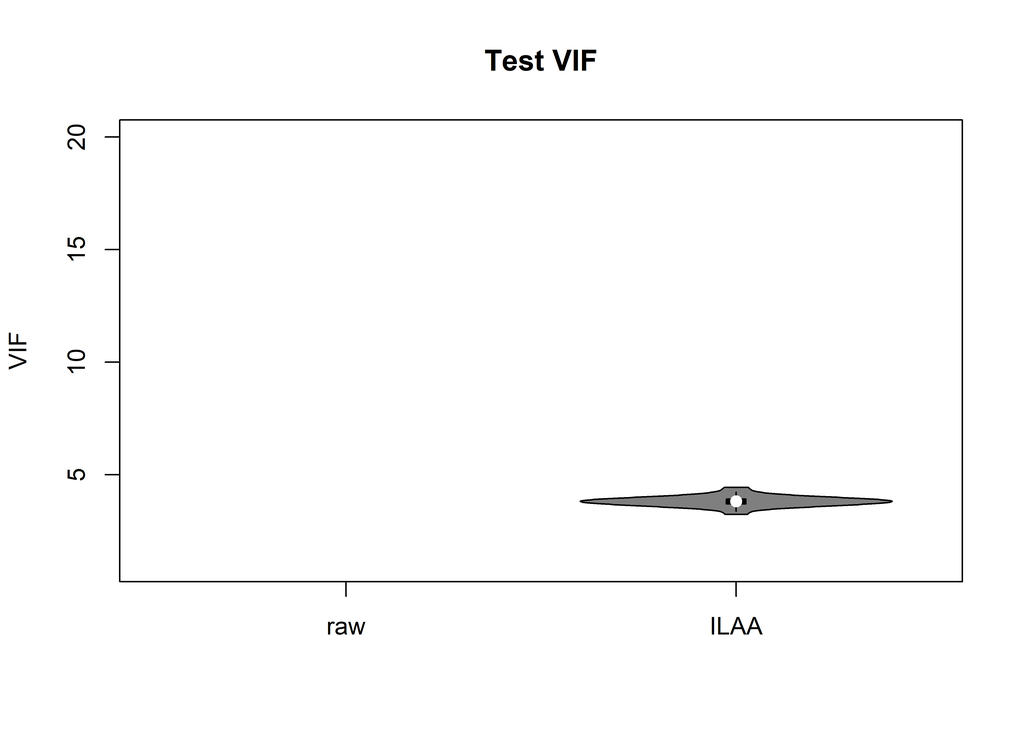

```r
sylim <- c(1,min(c(20,max(corresults$VIFRaw))))
vioplot(list(raw=corresults$VIFRaw,ILAA=corresults$VIFDe),
        ylab="VIF",
        ylim=sylim,
        main="Test VIF")
```

```r
pander::pander(summary(cbind(raw=corresults$VIFRaw,ILAA=corresults$VIFDe)))
```

| raw | ILAA |
| --- | --- |
| Min. : 88.00 | Min. :3.237 |
| 1st Qu.: 97.83 | 1st Qu.:3.697 |
| Median :100.02 | Median :3.804 |
| Mean : 97.64 | Mean :3.804 |
| 3rd Qu.:100.68 | 3rd Qu.:3.890 |
| Max. :102.33 | Max. :4.429 |

```r
summary(corresults$VIFRaw)
```

Min. 1st Qu. Median Mean 3rd Qu. Max. 88.00 97.83 100.02 97.64 100.68 102.33

### 1.2.11 The t-values

```r
par(op)
par(mfrow=c(1,2),cex=0.5)
plot(corresults$rawtValues,
     main="Raw: Univariate t-values vs Model t-values",
     xlab="Univariate",
     ylab="Model",
     xlim=xvals,
     ylim=xvals)

lmtvals <- lm(Model~.,corresults$rawtValues)
pred <- lmtvals$coefficients[1] + lmtvals$coefficients[2] * xvals
lines(x=xvals,y=pred,col="red")
text(xvals[1]+(xvals[2]-xvals[1])/2,xvals[2]-1,sprintf("Slope= %.2f",lmtvals$coefficients[2]))

pander::pander(summary(lmtvals))
```

|  | Estimate | Std. Error | t value | Pr(>\|t\|) |
| --- | --- | --- | --- | --- |
| **(Intercept)** | -0.576 | 0.07160 | -8.04 | 1.90e-15 |
| **Uni** | 0.216 | 0.00983 | 21.99 | 2.93e-92 |

Fitting linear model: Model ~ .

| Observations | Residual Std. Error | $R^2$ | Adjusted $R^2$ |
| --- | --- | --- | --- |
| 1398 | 2.58 | 0.257 | 0.257 |

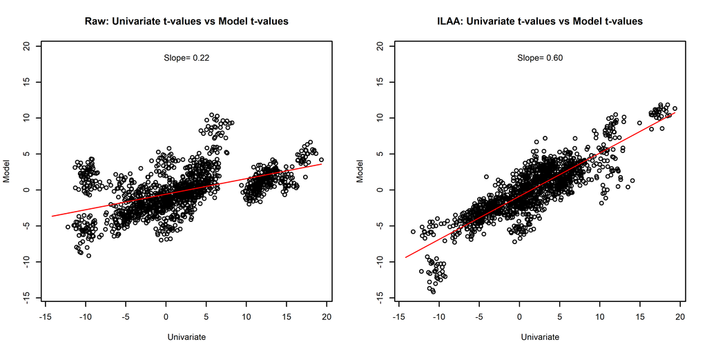

```r
plot(corresults$detValues,
      main="ILAA: Univariate t-values vs Model t-values",
     xlab="Univariate",
     ylab="Model",
     xlim=xvals,
     ylim=xvals)

lmtvals <- lm(Model~.,corresults$detValues)
pred <- lmtvals$coefficients[1] + lmtvals$coefficients[2] * xvals
lines(x=xvals,y=pred,col="red")
text(xvals[1]+(xvals[2]-xvals[1])/2,xvals[2]-1,sprintf("Slope= %.2f",lmtvals$coefficients[2]))
```

```r
pander::pander(summary(lmtvals))
```

|  | Estimate | Std. Error | t value | Pr(>\|t\|) |
| --- | --- | --- | --- | --- |
| **(Intercept)** | -0.870 | 0.05451 | -16.0 | 8.92e-53 |
| **Uni** | 0.601 | 0.00947 | 63.4 | 0.00e+00 |

Fitting linear model: Model ~ .

| Observations | Residual Std. Error | $R^2$ | Adjusted $R^2$ |
| --- | --- | --- | --- |
| 1381 | 1.96 | 0.745 | 0.745 |

## 1.3 The Age plots

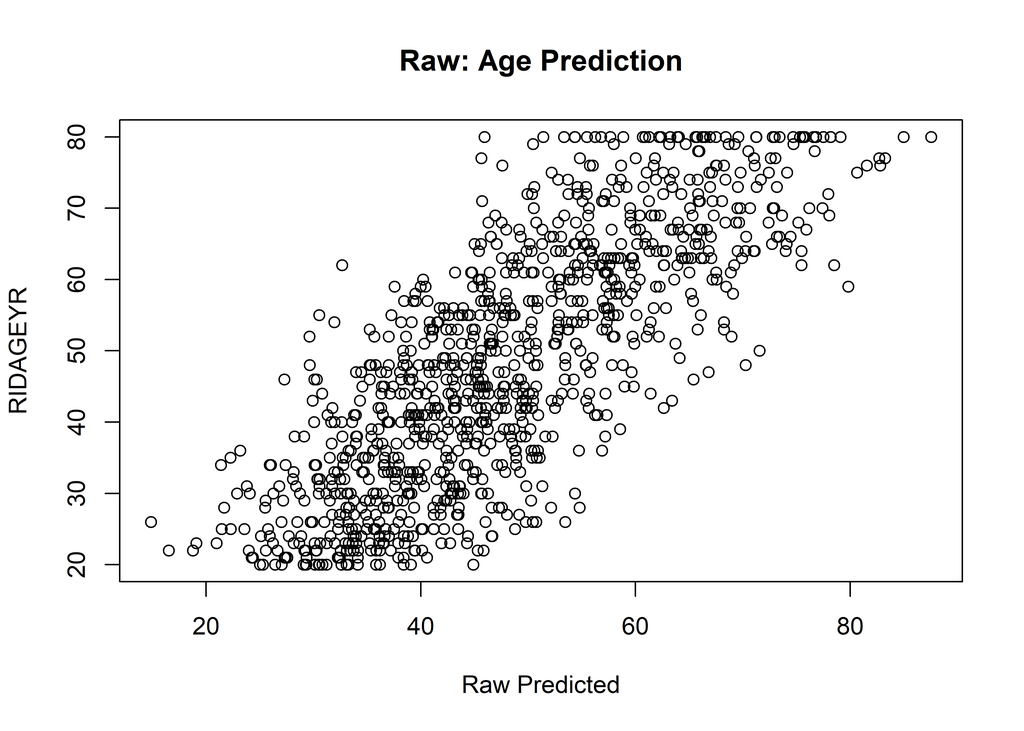

```r
plot(predOutcome,testingset[,outcome],xlab="Raw Predicted",ylab=outcome,main="Raw: Age Prediction")
```

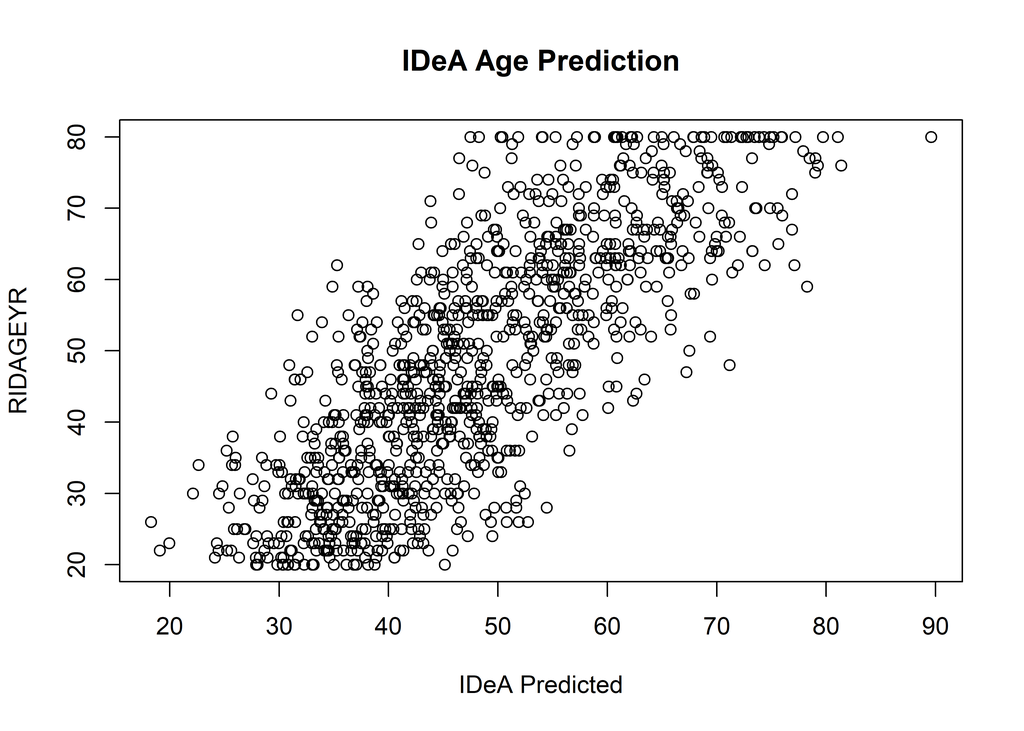

```r
plot(predOutcome_DE,testingset[,outcome],xlab="IDeA Predicted",ylab=outcome,main="IDeA Age Prediction")
```

## 1.4 Descriptors

```r
pander::pander(demographiDesc[demographiDesc$`Variable Name` %in% colnames(transform),c(1,2)])
```

|  | Variable Name | Variable Description |
| --- | --- | --- |
| **46** | WTINT2YR | Full sample 2 year interview weight. |
| **47** | WTMEC2YR | Full sample 2 year MEC exam weight. |

```r
pander::pander(examinationDesc[examinationDesc$`Variable Name` %in% colnames(transform),c(1,2)])
```

|  | Variable Name | Variable Description |
| --- | --- | --- |
| **12** | BPXML1 | MIL: maximum inflation levels (mm Hg) |
| **109** | BMXARMC | Arm Circumference (cm) |
| **110** | BMXARML | Upper Arm Length (cm) |
| **111** | BMXBMI | Body Mass Index (kg/m**2) |
| **113** | BMXHT | Standing Height (cm) |
| **114** | BMXLEG | Upper Leg Length (cm) |
| **120** | BMXWAIST | Waist Circumference (cm) |
| **121** | BMXWT | Weight (kg) |
| **175** | MGDCGSZ | Combined grip strength (kg): the sum of the largest reading from each hand. |
| **185** | MGXH1T1 | Grip strength (kg), hand 1, test 1 |
| **187** | MGXH1T2 | Grip strength (kg), hand 1, test 2 |
| **189** | MGXH1T3 | Grip strength (kg), hand 1, test 3 |
| **191** | MGXH2T1 | Grip strength (kg), hand 2, test 1 |
| **193** | MGXH2T2 | Grip strength (kg), hand 2, test 2 |
| **195** | MGXH2T3 | Grip strength (kg), hand 2, test 3 |
| **212** | OHX04TC | Tooth Count: Upper right 2nd bicuspid/2nd primary molar (2B) |
| **219** | OHX06TC | Tooth Count: Upper right cuspid (C) |
| **236** | OHX11TC | Tooth Count: Upper left cuspid (C) |
| **244** | OHX13TC | Tooth Count: Upper left 2nd bicuspid/2nd primary molar (2B) |
| **266** | OHX20TC | Tooth Count: Lower left 2nd bicuspid/2nd primary molar (2B) |
| **282** | OHX25TC | Tooth Count: Lower right central incisor (CI) |
| **296** | OHX29TC | Tooth Count: Lower right 2nd bicuspid/2nd primary molar (2B) |

```r
pander::pander(questionnaireDesc[questionnaireDesc$`Variable Name` %in% colnames(transform),c(1,2)])
```

| **Variable Name** | **Variable Description** |
| --- | --- |

```r
pander::pander(labsDesc[labsDesc$`Variable Name` %in% colnames(transform),c(1,2)])
```

|  | Variable Name | Variable Description |
| --- | --- | --- |
| **5** | LBDBANO | Basophils number (1000 cells/uL) |
| **6** | LBDEONO | Eosinophils number (1000 cells/uL) |
| **7** | LBDLYMNO | Lymphocyte number (1000 cells/uL) |
| **8** | LBDMONO | Monocyte number (1000 cells/uL) |
| **9** | LBDNENO | Segmented neutrophils num (1000 cell/uL) |
| **10** | LBXBAPCT | Basophils percent (%) |
| **11** | LBXEOPCT | Eosinophils percent (%) |
| **12** | LBXHCT | Hematocrit (%) |
| **13** | LBXHGB | Hemoglobin (g/dL) |
| **14** | LBXLYPCT | Lymphocyte percent (%) |
| **15** | LBXMC | Mean cell hemoglobin concentration (g/dL) |
| **16** | LBXMCHSI | Mean cell hemoglobin (pg) |
| **17** | LBXMCVSI | Mean cell volume (fL) |
| **18** | LBXMOPCT | Monocyte percent (%) |
| **19** | LBXMPSI | Mean platelet volume (fL) |
| **20** | LBXNEPCT | Segmented neutrophils percent (%) |
| **21** | LBXPLTSI | Platelet count (1000 cells/uL) |
| **22** | LBXRBCSI | Red blood cell count (million cells/uL) |
| **24** | LBXWBCSI | White blood cell count (1000 cells/uL) |
| **26** | LBDHDD | Direct HDL-Cholesterol (mg/dL) |
| **27** | LBDHDDSI | Direct HDL-Cholesterol (mmol/L) |
| **29** | LBDTCSI | Total Cholesterol( mmol/L) |
| **30** | LBXTC | Total Cholesterol( mg/dL) |
| **1413** | LBXHCT | Hydroxycotinine, Serum (ng/mL) |
| **1452** | URDACT | Albumin creatinine ratio (mg/g) |
| **1453** | URXCRS | Creatinine, urine (umol/L) |
| **1455** | URXUMA | Albumin, urine (ug/mL) |
| **1456** | URXUMS | Albumin, urine (mg/L) |